# Week 3 Project

P.M.

2024-04-05

## Step 1: Source information

**Question to Answer:** What are some of the demographic trends we can see in the shootings?

## Step 1: Source information

The first thing we did was to find a reliable source of data of the historic Shooting data for New York and so decided to use data from a US government Data site: “https://catalog.data.gov/dataset”, particularly in the data set titled: NYPD Shooting Incident Data (Historic).

*Note: We used the tidyverse package to tidy in our data*

### Importing Data:

We imported our data as a CSV file from this link: https://data.cityofnewyork.us/api/views/833y-fsy8/rows.csv?accessType=DOWNLOAD

```r
library(readr)
Shooting_Data_main <- read_csv("https://data.cityofnewyork.us/api/views/833y-fsy8/rows.csv?accessType=DOWNLOAD")
summary(Shooting_Data_main)
```

```
##   INCIDENT_KEY        OCCUR_DATE         OCCUR_TIME           BORO
##  Min.   :  9953245   Length:28562       Length:28562      Length:28562
##  1st Qu.: 65439914   Class :character   Class1:hms        Class :character
##  Median : 92711254   Mode  :character   Class2:difftime   Mode  :character
##  Mean   :127405824                      Mode  :numeric
##  3rd Qu.:203131993
##  Max.   :279758069
##
##  LOC_OF_OCCUR_DESC     PRECINCT     JURISDICTION_CODE LOC_CLASSFCTN_DESC
##  Length:28562       Min.   :  1.0   Min.   :0.0000    Length:28562
##  Class :character   1st Qu.: 44.0   1st Qu.:0.0000    Class :character
##  Mode  :character   Median : 67.0   Median :0.0000    Mode  :character
##                     Mean   : 65.5   Mean   :0.3219
##                     3rd Qu.: 81.0   3rd Qu.:0.0000
##                     Max.   :123.0   Max.   :2.0000
##                                     NA's   :2
##  LOCATION_DESC      STATISTICAL_MURDER_FLAG PERP_AGE_GROUP
##  Length:28562       Mode :logical           Length:28562
##  Class :character   FALSE:23036             Class :character
##  Mode  :character   TRUE :5526              Mode  :character
##
##
##
##
##    PERP_SEX          PERP_RACE         VIC_AGE_GROUP        VIC_SEX
##  Length:28562       Length:28562       Length:28562       Length:28562
##  Class :character   Class :character   Class :character   Class :character
##  Mode  :character   Mode  :character   Mode  :character   Mode  :character
##
##
##
##
##    VIC_RACE           X_COORD_CD        Y_COORD_CD        Latitude
##  Length:28562       Min.   : 914928   Min.   :125757   Min.   :40.51
##  Class :character   1st Qu.:1000068   1st Qu.:182912   1st Qu.:40.67
##  Mode  :character   Median :1007772   Median :194901   Median :40.70
##                     Mean   :1009424   Mean   :208380   Mean   :40.74
##                     3rd Qu.:1016807   3rd Qu.:239814   3rd Qu.:40.82
##                     Max.   :1066815   Max.   :271128   Max.   :40.91
##                                                        NA's   :59
##    Longitude        Lon_Lat
##  Min.   :-74.25   Length:28562
##  1st Qu.:-73.94   Class :character
##  Median :-73.92   Mode  :character
##  Mean   :-73.91
##  3rd Qu.:-73.88
##  Max.   :-73.70
##  NA's   :59
```

## Step 2: Tidying the Data:

After importing the data, I read through it to see if it needs any tidying or if it’s missing any information:

1. **Changing the date to a date object**:

```r
#installing needed libraries
library(dplyr)
library(lubridate)
Shooting_Data_main <- Shooting_Data_main %>% mutate(OCCUR_DATE = mdy(OCCUR_DATE))
```

2. **Removing columns we will not use**

   We view all the columns and identified 9 columns we won’t need for our analysis, so we removed columns like, Jurisdiction_code, statistical_murder_flag, latitude as seen below:

   ```r
   to_remove <- c("JURISDICTION_CODE","STATISTICAL_MURDER_FLAG","Latitude","X_COORD_CD","Longitude","Y_COORD_CD","Lon_Lat","LOC_CLASSFCTN_DESC","LOC_OF_OCCUR_DESC")

   Shooting_Data_main <- Shooting_Data_main[,!(names(Shooting_Data_main) %in% to_remove)]
   ```

   We also filtered out columns with empty values like LOC_CLASSFCTN_DESC and LOC_OF_OCCUR_DESC.
3. Filtering out empty values such as NA and UNKOWN in the Race and age groups catergories:

   **Removing NA values**:

   ```r
   Shooting_Data_main <- na.omit(Shooting_Data_main)
   ```

   **Removing all “UNKOWN” values**

   The PERP_AGE_GROUP column had many unknown values so we filtered them out:

   ```r
   Shooting_Data_main <- Shooting_Data_main %>% filter(PERP_AGE_GROUP != "UNKNOWN")
   ```

   **Missing and incorrect values**

   At the end this is how the data looks:

   ```r
   summary(Shooting_Data_main)
   ```

   ```
   ##   INCIDENT_KEY         OCCUR_DATE          OCCUR_TIME           BORO
   ##  Min.   :  9953245   Min.   :2006-01-01   Length:8842       Length:8842
   ##  1st Qu.: 71514503   1st Qu.:2010-02-27   Class1:hms        Class :character
   ##  Median :150339140   Median :2016-02-12   Class2:difftime   Mode  :character
   ##  Mean   :152522271   Mean   :2016-01-13   Mode  :numeric
   ##  3rd Qu.:246530273   3rd Qu.:2022-06-12
   ##  Max.   :279758069   Max.   :2023-12-29
   ##     PRECINCT      LOCATION_DESC      PERP_AGE_GROUP       PERP_SEX
   ##  Min.   :  1.00   Length:8842        Length:8842        Length:8842
   ##  1st Qu.: 43.00   Class :character   Class :character   Class :character
   ##  Median : 67.00   Mode  :character   Mode  :character   Mode  :character
   ##  Mean   : 64.18
   ##  3rd Qu.: 81.00
   ##  Max.   :123.00
   ##   PERP_RACE         VIC_AGE_GROUP        VIC_SEX            VIC_RACE
   ##  Length:8842        Length:8842        Length:8842        Length:8842
   ##  Class :character   Class :character   Class :character   Class :character
   ##  Mode  :character   Mode  :character   Mode  :character   Mode  :character
   ##
   ##
   ##
   ```

   For the rest of the missing values in some of the columns for example in perpetrator age groups there were some unknown values in some rows, as we go along in doing our analysis, we will check to see if there are any missing values and adjust appropriately.

## Step 3: Analyzing the Data:

After cleaning and importing the data we will now analyze the data, particularly looking at the demographic statistics within the data.

#### 1. Looking at the Boroughs affected over the years:

- First we start by looking at the total number of shootings in the different boroughs to see the highest and lowest:

  ```r
  Boro_Sum <- Shooting_Data_main %>% count(BORO)
  print(Boro_Sum)
  ```

  ```
  ## # A tibble: 5 × 2
  ##   BORO              n
  ##   <chr>         <int>
  ## 1 BRONX          2661
  ## 2 BROOKLYN       3201
  ## 3 MANHATTAN      1378
  ## 4 QUEENS         1286
  ## 5 STATEN ISLAND   316
  ```

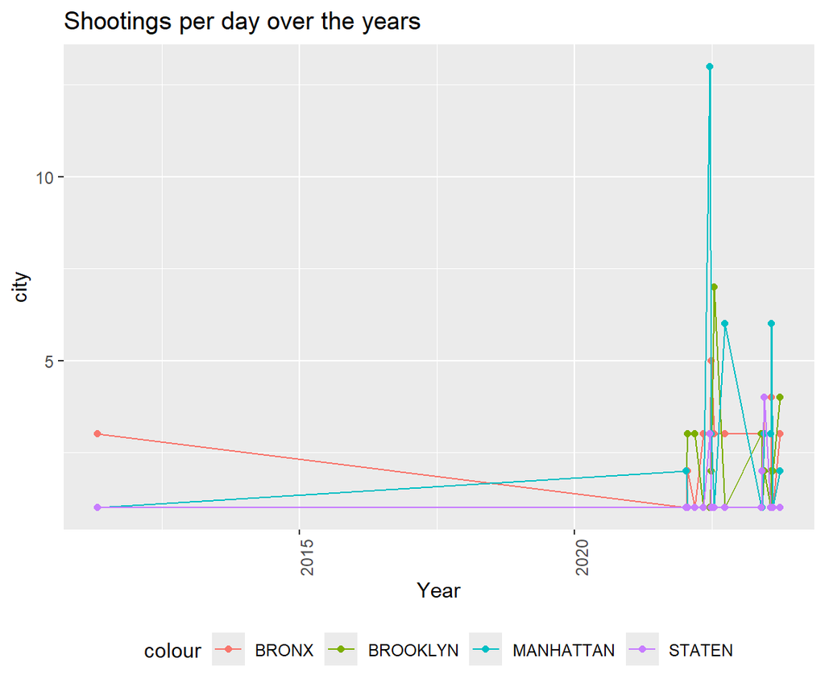

  ```r
  library(ggplot2)
  # Organising the data by Borough and by the date
  Bronx <- Shooting_Data_main %>% filter(BORO == "BRONX")
  Bronx_date <- Bronx %>% count(OCCUR_DATE)
  Bronx_date <- Bronx_date %>% rename(BRONX = n)

  BROOKLYN <- Shooting_Data_main %>% filter(BORO == "BROOKLYN")
  BROOKLYN_date <- BROOKLYN %>% count(OCCUR_DATE)
  BROOKLYN_date <- BROOKLYN_date %>% rename(BROOKLYN = n)

  MANHATTAN <- Shooting_Data_main %>% filter(BORO == "MANHATTAN")
  MANHATTAN_date <- MANHATTAN %>% count(OCCUR_DATE)
  MANHATTAN_date <- MANHATTAN_date %>% rename(MANHATTAN = n)

  QUEENS <- Shooting_Data_main %>% filter(BORO == "QUEENS")
  QUEENS_date <- QUEENS %>% count(OCCUR_DATE)
  QUEENS_date <- QUEENS_date %>% rename(QUEENS = n)

  STATEN_ISLAND <- Shooting_Data_main %>% filter(BORO == "STATEN ISLAND")
  STATEN_ISLAND_date <- STATEN_ISLAND %>% count(OCCUR_DATE)
  STATEN_ISLAND_date <- STATEN_ISLAND_date %>% rename(STATEN = n)

  #Merging them into one Dataframe and the number of deaths for each Borough at each date:
  BOROS <- merge(merge(merge(Bronx_date,BROOKLYN_date, by = "OCCUR_DATE"), MANHATTAN_date, by = "OCCUR_DATE"), STATEN_ISLAND_date, by = "OCCUR_DATE")

  #Plotting it on a graph

  ggplot(BOROS, aes(x = OCCUR_DATE)) + geom_line(aes(y = BRONX, color="BRONX")) + geom_point(aes(y = BRONX, color="BRONX"))+ geom_line(aes(y=BROOKLYN, color="BROOKLYN"))+ geom_point(aes(y=BROOKLYN, color="BROOKLYN")) + geom_line(aes(y=MANHATTAN,color="MANHATTAN")) + geom_point(aes(y=MANHATTAN,color="MANHATTAN")) + geom_line(aes(y=STATEN,color="STATEN")) + geom_point(aes(y=STATEN,color="STATEN")) + labs(x = "Year", y = "city", title="Shootings per day over the years") + theme(legend.position = "bottom", axis.text.x = element_text(angle = 90))
  ```

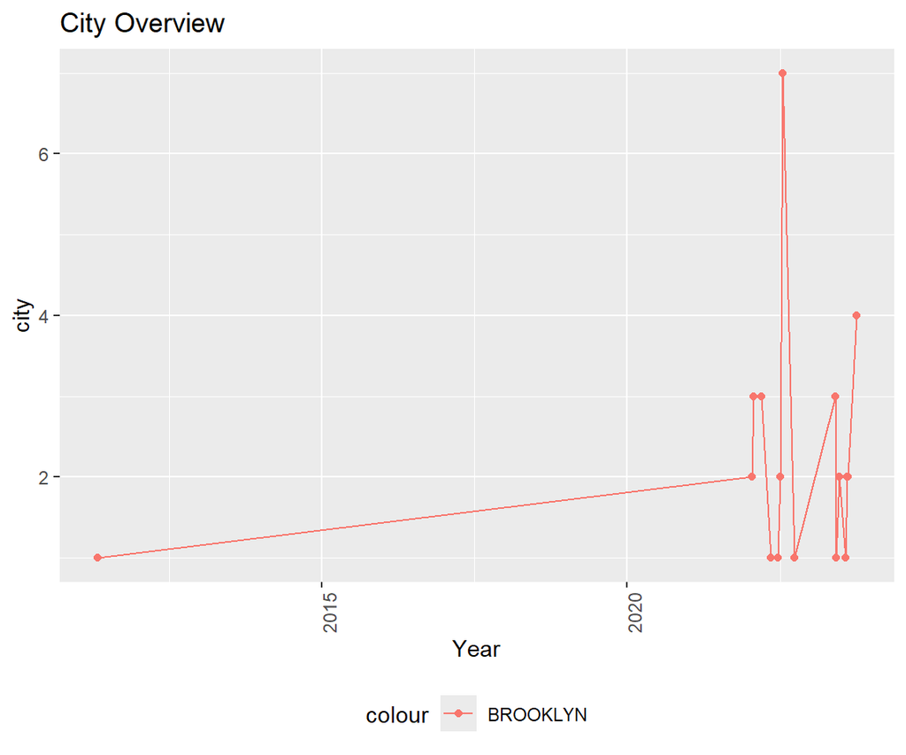

  ```r
  ggplot(BOROS, aes(x = OCCUR_DATE)) + geom_line(aes(y=BROOKLYN, color="BROOKLYN"))+ geom_point(aes(y=BROOKLYN, color="BROOKLYN")) + labs(x = "Year", y = "city", title="City Overview") + theme(legend.position = "bottom", axis.text.x = element_text(angle = 90))
  ```

##### **Additional Questions:**

  1. One question raised would be the population between cities, is the high deaths in Brooklyn a result of a higher population or higher crime rate?
  2. Another would be what caused the spike in 2022 and above, would it be a new government policy, or the immigration crisis, or something else?

#### 2. Age Groups

We also looked at what age groups are the victims and the perpetrators of the crime.

We started of with the **victims** as seen below in the graph:

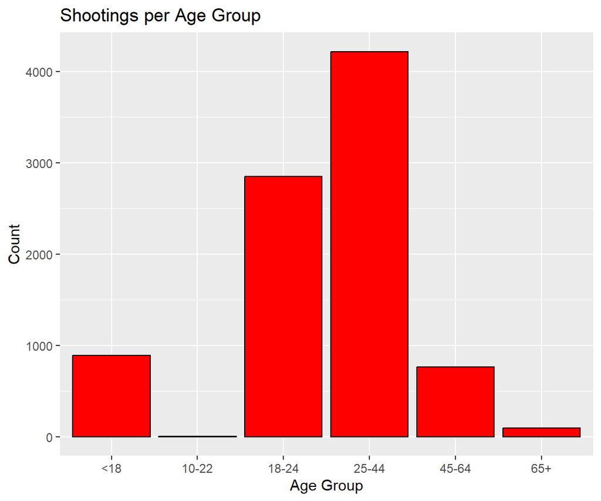

```r
#Organising by age groups
histgm <- Shooting_Data_main %>% count(VIC_AGE_GROUP)
histgm[1,1] <- "10-22"
histgm1 <- histgm[-7,]
ggplot(histgm1, aes(x=VIC_AGE_GROUP,y=n)) + geom_bar(stat="identity",fill = "red",color = "black")+ labs(x="Age Group",y="Count", title = "Shootings per Age Group")
```

We also did some cleaning of the data, removing “UNKNOWN” values and editing the age group text from “**1022**” to “**10-22**”.

**Analysis**: From the graph above we see that the largest groups are between 18-24, and and 25-44. This makes sense in that these are the most active groups in any society.

We also looked at the **prepetrators** age group:

```r
#Organising by perp age groups
prepbar <- Shooting_Data_main %>% count(PERP_AGE_GROUP)
print(prepbar)
```

```
## # A tibble: 10 × 2
##    PERP_AGE_GROUP     n
##    <chr>          <int>
##  1 (null)          1141
##  2 1020               1
##  3 1028               1
##  4 18-24           3182
##  5 224                1
##  6 25-44           3227
##  7 45-64            421
##  8 65+               47
##  9 940                1
## 10 <18              820
```

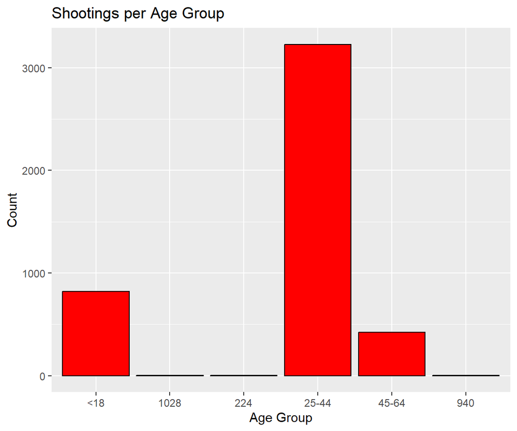

```r
prepbar <- prepbar[-c(1,2,4,8),]
ggplot(prepbar, aes(x=PERP_AGE_GROUP,y=n)) + geom_bar(stat="identity",fill = "red",color = "black")+ labs(x="Age Group",y="Count", title = "Shootings per Age Group")
```

##### **Additional Questions raised**:

1. What is the population between the different age groups from the victims to the perpetrator. This might raise question as to whether the rates of crime committed at the different age groups is a result of population and not other factors such as economic status and so forth.
2. What was the reason for the shooting, was it a robbery related crime, a gang violence related crime, domestic or civil case. This would help in understanding what factors cause shootings the most.

#### 3. Gender

We also look at the gender demographics of the shooters and the victims.

We first started with the **perpetrators**:

```r
race_pie <- Shooting_Data_main %>% count(PERP_SEX)
print(race_pie)
```

```
## # A tibble: 4 × 2
##   PERP_SEX     n
##   <chr>    <int>
## 1 (null)    1141
## 2 F          259
## 3 M         7434
## 4 U            8
```

After this we clean the data to remove null values:

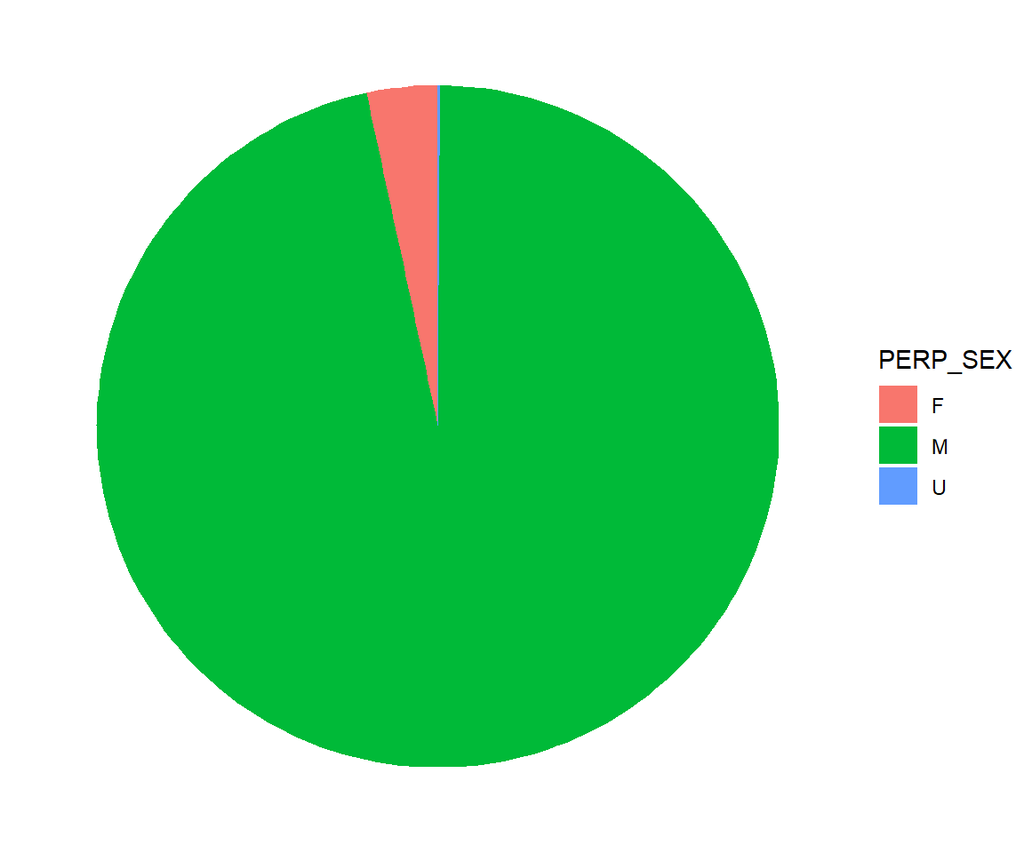

```r
#removing empty/null values
race_pie <- race_pie[-1,]
ggplot(race_pie,aes(x = "", y = n, fill = PERP_SEX))+ geom_bar(stat="identity",width = 1) + coord_polar("y", start = 0) + theme_void() + theme(legend.position = "right")
```

From here we can see there was a high ratio of male perpetrators (96%). We see it more in detail below in a bar graph that there were over 6000 shootings by male perpetrators and less than 500 for the rest:

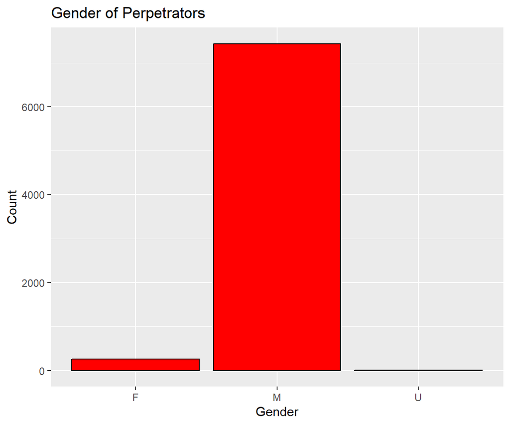

```r
ggplot(race_pie, aes(x=PERP_SEX,y=n)) + geom_bar(stat="identity",fill = "red",color = "black")+ labs(x="Gender",y="Count", title = "Gender of Perpetrators")
```

Then looking at the **victims** as shown below:

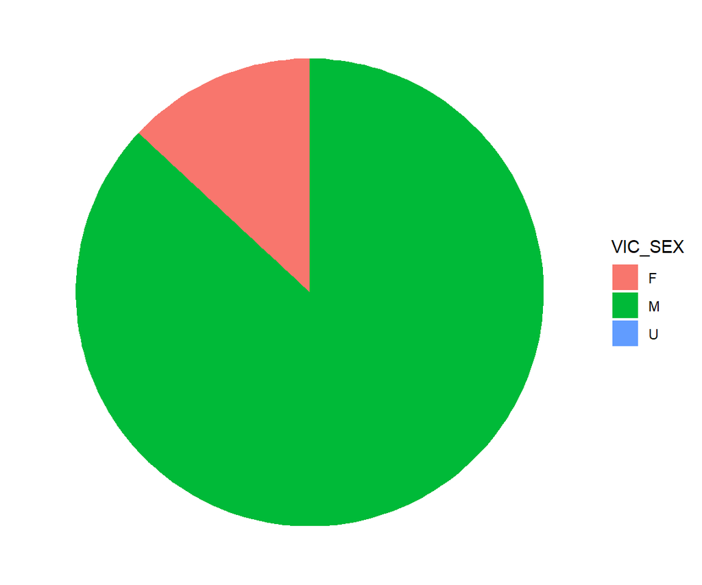

```r
race_pie_vic <- Shooting_Data_main %>% count(VIC_SEX)
ggplot(race_pie_vic,aes(x = "", y = n, fill = VIC_SEX))+ geom_bar(stat="identity",width = 1) + coord_polar("y", start = 0) + theme_void() + theme(legend.position = "right")
```

From here we see similar trend of having a significantly higher number of male vitctims, however it’s lesser here by by about 10% (86%) than for perpetrators. We see it more in detail below:

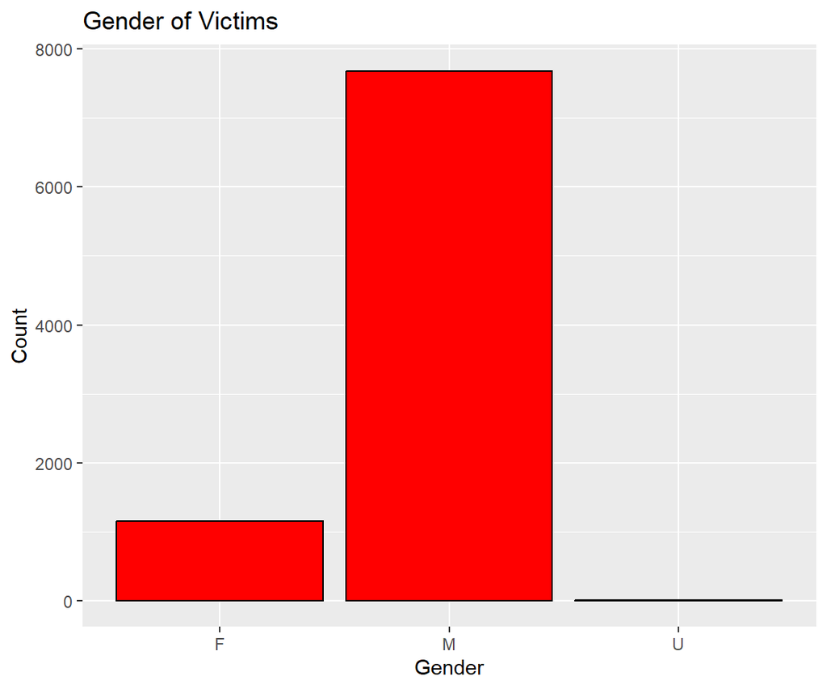

```r
ggplot(race_pie_vic, aes(x=VIC_SEX,y=n)) + geom_bar(stat="identity",fill = "red",color = "black")+ labs(x="Gender",y="Count", title = "Gender of Victims")
```

From here we see that male victims were over 6000 but female victims were just about 1000. This raises more questions:

1. What was the reason/cause of the shooting, were the high male to male shootings a result of gang violence or other causes?
2. What is the population distribution of males, is this the cause of the high numbers?

#### 4. Predicting Model of Age Group VS Race

I also looked at the relation between race and age group for perpetrators, to understand if it race was a factor that affected the distribution of shootings between age groups.

To start it of, we first looked at shootings from between 2006 to 2011 (5 year period), looking at the percentages between the age groups and we used this to train our model. We then looked test the model with data from 2011 to 2016 (5 year period) to see if our model accurately represented the data.

```r
mod_used <- Shooting_Data_main %>% filter(year(OCCUR_DATE) <= 2011) %>% count(PERP_AGE_GROUP)
print(mod_used)
```

```
## # A tibble: 6 × 2
##   PERP_AGE_GROUP     n
##   <chr>          <int>
## 1 18-24           1501
## 2 224                1
## 3 25-44           1144
## 4 45-64            109
## 5 65+               10
## 6 <18              359
```

```
## `geom_line()`: Each group consists of only one observation.
## ℹ Do you need to adjust the group aesthetic?
## `geom_line()`: Each group consists of only one observation.
## ℹ Do you need to adjust the group aesthetic?
```

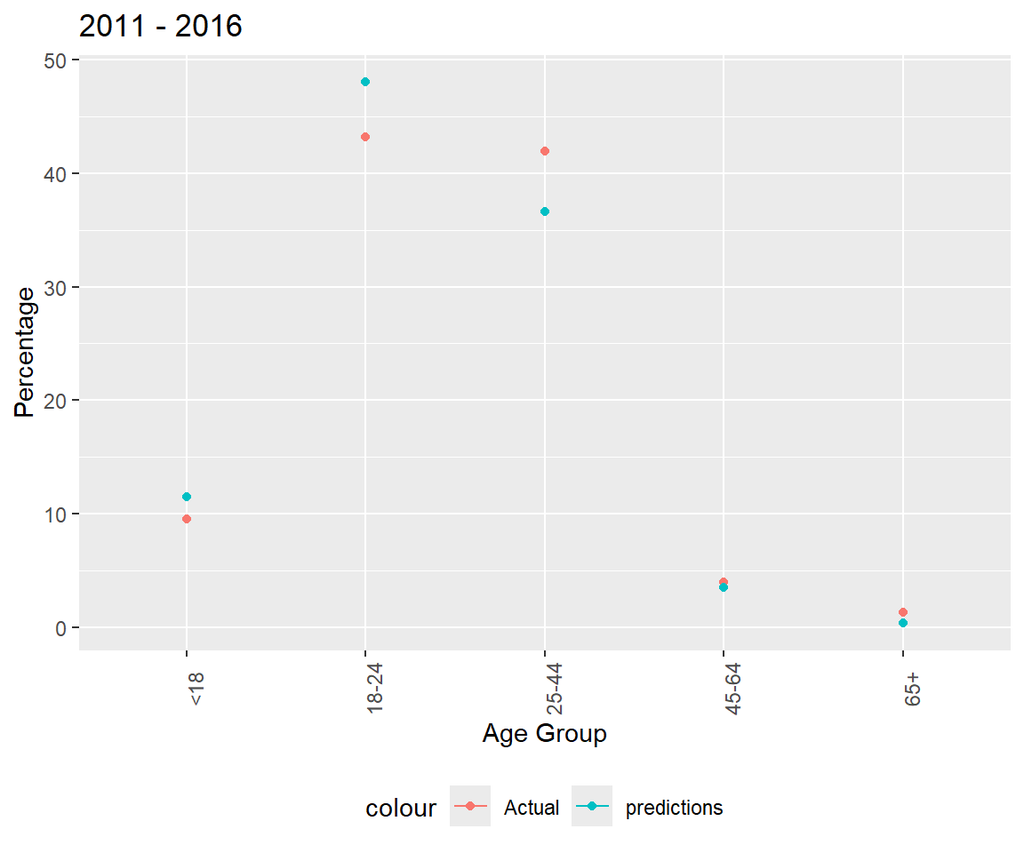

```r
#Cleaning it to remove unwanted data:
mod_used <- mod_used[-2,]

#Getting the percentage distribution of the different age groups:
total_count <- sum(mod_used$n)
mod_used <- mod_used %>% mutate(percentage = n / total_count *100)

#making a prediction of the data:
preditions <- lm(percentage ~ PERP_AGE_GROUP, data=mod_used)

#data we will use to test our model:
test_mod <- Shooting_Data_main %>% filter(year(OCCUR_DATE) > 2011 & year(OCCUR_DATE) <= 2016) %>% count(PERP_AGE_GROUP)

#cleaning up the data and getting percentage ratios:
test_mod <- test_mod[-c(1,6),]
total_count <- sum(test_mod$n)
test_mod <- test_mod %>% mutate(percentage = n / total_count *100)

#predicting the data:
test_mod$predictions <- predict(preditions, newdata = test_mod)

ggplot(test_mod, aes(x = PERP_AGE_GROUP)) + geom_line(aes(y=percentage, color="Actual"))+ geom_point(aes(y=percentage, color="Actual"))+ geom_line(aes(y=predictions, color="predictions"))+ geom_point(aes(y=predictions, color="predictions")) + labs(x = "Age Group", y = "Percentage", title="2011 - 2016") + theme(legend.position = "bottom", axis.text.x = element_text(angle = 90))
```

From below, we see that our predicted values closely imitate the actual values. now to test our theory, we looked at data from the 2 races with the highest shootings, that is Black and White Hispanic.

Starting with **Black**

```
## `geom_line()`: Each group consists of only one observation.
## ℹ Do you need to adjust the group aesthetic?
## `geom_line()`: Each group consists of only one observation.
## ℹ Do you need to adjust the group aesthetic?
```

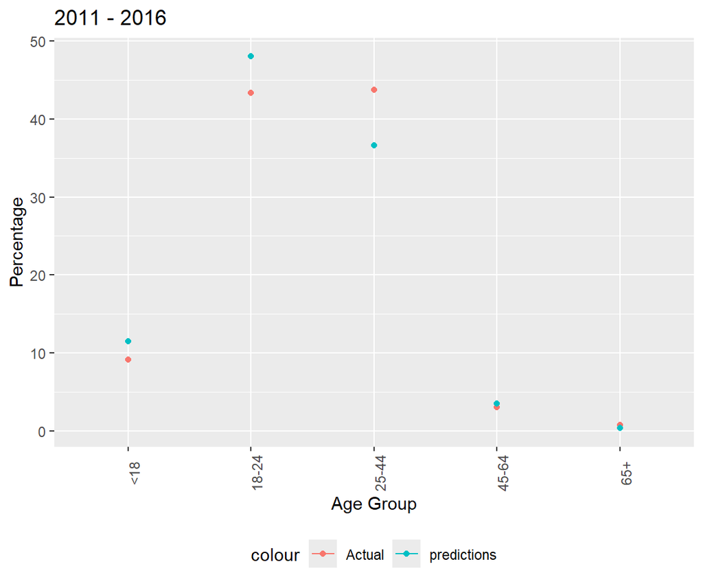

```r
Black <- test_mod <- Shooting_Data_main %>% filter(year(OCCUR_DATE) > 2011 & year(OCCUR_DATE) <= 2016) %>% filter(PERP_RACE == "BLACK")%>% count(PERP_AGE_GROUP)

Black <- Black[-1,]
total_count <- sum(Black$n)
Black <- Black %>% mutate(percentage = n / total_count *100)
Black$predictions <- predict(preditions, newdata = Black)
ggplot(Black, aes(x = PERP_AGE_GROUP)) + geom_line(aes(y=percentage, color="Actual"))+ geom_point(aes(y=percentage, color="Actual"))+ geom_line(aes(y=predictions, color="predictions"))+ geom_point(aes(y=predictions, color="predictions")) + labs(x = "Age Group", y = "Percentage", title="2011 - 2016") + theme(legend.position = "bottom", axis.text.x = element_text(angle = 90))
```

We can see it’s following a similar pattern , however in this case our predictions are sometimes lower and sometimes higher than the actual values, but nothing significant showing a difference here.

I did the same for **White-Hispanic**

```
## `geom_line()`: Each group consists of only one observation.
## ℹ Do you need to adjust the group aesthetic?
## `geom_line()`: Each group consists of only one observation.
## ℹ Do you need to adjust the group aesthetic?
```

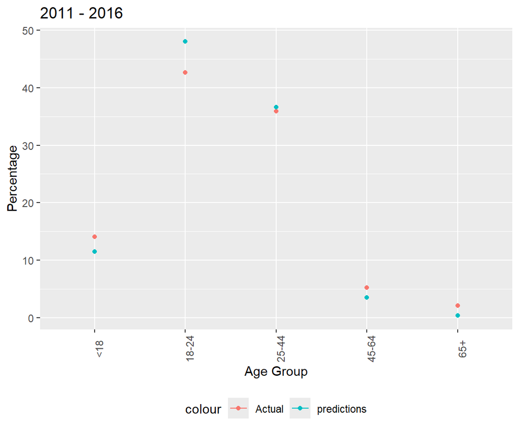

```r
White <- Shooting_Data_main %>% filter(year(OCCUR_DATE) > 2011 & year(OCCUR_DATE) <= 2016) %>% filter(PERP_RACE == "WHITE HISPANIC")%>% count(PERP_AGE_GROUP)
White <- White[-5,]
total_count <- sum(White$n)
White <- White %>% mutate(percentage = n / total_count *100)
White$predictions <- predict(preditions, newdata = White)

ggplot(White, aes(x = PERP_AGE_GROUP)) + geom_line(aes(y=percentage, color="Actual"))+ geom_point(aes(y=percentage, color="Actual"))+ geom_line(aes(y=predictions, color="predictions"))+ geom_point(aes(y=predictions, color="predictions")) + labs(x = "Age Group", y = "Percentage", title="2011 - 2016") + theme(legend.position = "bottom", axis.text.x = element_text(angle = 90))
```

Here we see a similar trend where the predictions are not too far off from the actual values. This therefore concludes that race does not affect age group.

#### 5. Conclusion and possible bias:

**Possible Sources of Bias**: From my own knowledge and understanding of New York and especially some of the challenges facing youths I already came into the research expecting a certain criteria and demographic of perpetrators of gun violence. However to mitigate this, I looked at the overall age groups to understand what were their numbers and let the data speak for itself and only analyzed it from the insights I was getting from the data and not what I already now.

Another source of Bias is personal interest, particularly in the analysis, I was interested in just knowing one aspect, which was the race divisions of the shootings, however to mitigate this, I looked at many aspects other than just race, looked at location, gender and age group to have a balance of insights.